# BCB420 Assignment 1

Feiyang Sun

2026-02-10

# 1 Introduction

## 1.1 Paper Overview

In this assignment, I selected the RNA-seq dataset (GEO accession: GSE263406) from a study (Tan et al., 2025) investigating how nonsense-mediated RNA decay (NMD) (Karousis et al., 2016) is regulated in a cell type-specific manner during human neural development. The study shows that NMD sensitivity is strongly influenced by cellular context, with hundreds of transcripts becoming either more sensitive or resistant to NMD as human embryonic stem cells (hESCs) differentiate into neural progenitor cells (NPCs). It also reveals that the NMD factor UPF3B regulates a distinct subset of targets compared to the core factor UPF2.

Overall, the dataset consists of bulk RNA-seq data from NPCs differentiated from hESCs, comparing control and UPF3B knockout (KO) groups to identify UPF3B-dependent NMD target transcripts.

## 1.2 Dataset Selection

I found and chose this dataset by searching through the GEO database website. This dataset profiles human embryonic stem cells differentiating into neural progenitor cells, including control and UPF3B knockout groups. I am interested in exploring how cellular context affects nonsense-mediated RNA decay (NMD) and gene expression. The high-quality bulk RNA-seq data is well-suited for cleaning, normalization, and differential expression analysis.

## 1.3 Package installation

All packages required for subsequent analyses were checked for installation and loaded into the R environment. Make sure to install and load packages from Bioconductor (Morgan & Ramos, 2025).

```r
if(!requireNamespace("knitr", quietly = TRUE)) {
  install.packages("knitr")
}

if(!requireNamespace("dplyr", quietly = TRUE)) {
  install.packages("dplyr")
}

if(!requireNamespace("readr", quietly = TRUE)) {
  install.packages("readr")
}

if(!requireNamespace("rmarkdown", quietly = TRUE)) {
  install.packages("rmarkdown")
}

if(!requireNamespace("tidyr", quietly = TRUE)) {
  install.packages("tidyr")
}

if(!requireNamespace("patchwork", quietly = TRUE)) {
  install.packages("patchwork")
}

if(!requireNamespace("tibble", quietly = TRUE)) {
  install.packages("tibble")
}

if(!requireNamespace("BiocManager", quietly = TRUE)) {
  install.packages("BiocManager")
}

if(!requireNamespace("ggplot2", quietly = TRUE)) {
  install.packages("ggplot2")
}

if(!requireNamespace("ggrepel", quietly = TRUE)) {
  install.packages("ggrepel")
}

if(!requireNamespace("circlize", quietly = TRUE)) {
  install.packages("circlize")
}

if(!requireNamespace("RColorBrewer", quietly = TRUE)) {
  install.packages("RColorBrewer")
}

# Install and load packages from Bioconductor

if(!requireNamespace("circlize", quietly = TRUE)) {
  BiocManager::install("circlize")
}

if(!requireNamespace("ComplexHeatmap", quietly = TRUE)) {
  BiocManager::install("ComplexHeatmap")
}

if(!requireNamespace("preprocessCore", quietly = TRUE)) {
  BiocManager::install("preprocessCore")
}

if(!requireNamespace("GEOquery", quietly = TRUE)) {
  BiocManager::install("GEOquery")
}

if(!requireNamespace("biomaRt", quietly = TRUE)) {
  BiocManager::install("biomaRt")
}
```

# 2 Dataset assessing, cleaning, and mapping

## 2.1 Downloading data from GEO

The bulk mRNA-seq dataset was on the Gene Expression Omnibus (GEO) with accession GSE263406, and could be accessed through R using the `GEOquery` package (Davis & Meltzer, 2007). Genes with no expression across all samples are removed.

```r
# Load relevant libraries
library("readr")
library("rmarkdown")
library("knitr")
library("GEOquery")

# Retrieve data from GEO
gseid <- "GSE263406"
if(!file.exists("GSE263406/GSE263406_rawcounts.txt.gz")) {
  getGEOSuppFiles(gseid, makeDirectory = TRUE)
}

# Read in the dataset
raw_counts <- read.table("GSE263406/GSE263406_rawcounts.txt.gz",
                         header = TRUE)
# dim(raw_counts) # 61551    18

# Remove genes with no expression across all samples
raw_counts_filtered <- raw_counts[rowSums(raw_counts[, 7:18]) != 0, ]
# dim(raw_counts_filtered) # 43884    18

# Display first 10 rows and columns
paged_table(raw_counts_filtered[1:10, 1:10])
```

|  | Geneid | Chr | Start | End | Strand | Length | Ctrl_1 | Ctrl_2 | Ctrl_3 | Ctrl_4 |
| --- | --- | --- | --- | --- | --- | --- | --- | --- | --- | --- |
| 1 | ENSG00000289719 | 11;11 | 71927578;71928365 | 71928035;71928447 | -;- | 541 | 22 | 5 | 22 | 9 |
| 3 | ENSG00000289716 | 11;11;11;11;11;11;11;11;11;11;11;11;11;11;11;11;11;11;11;11;11;11;11;11;11;11;11;11;11;11;11;11;11;11;11 | 71804997;71806230;71806240;71807591;71816910;71818153;71818153;71818153;71818153;71818773;71818773;71818773;71819645;71819645;71819645;71821465;71821465;71821465;71825234;71826300;71916074;71916074;71… | 71807656;71807656;71807656;71807656;71817096;71818235;71818238;71818235;71818235;71818868;71818868;71818868;71819771;71819771;71819771;71821547;71821547;71821547;71825278;71826627;71916234;71916252;71… | -;-;-;-;-;-;-;-;-;-;-;-;-;-;-;-;-;-;-;-;-;-;-;-;-;-;-;-;-;-;-;-;-;-;- | 4691 | 0 | 5 | 0 | 1 |
| 4 | ENSG00000289715 | 1;1 | 21547404;21553978 | 21547522;21554002 | +;+ | 144 | 0 | 1 | 0 | 0 |
| 10 | ENSG00000289709 | 5;5;5 | 56766395;56771505;56772773 | 56771152;56771756;56772875 | -;-;- | 5113 | 0 | 0 | 1 | 0 |
| 12 | ENSG00000289707 | Y;Y;Y;Y;Y;Y;Y;Y;Y;Y;Y;Y;Y;Y | 21138633;21138633;21148419;21148419;21151589;21151589;21152839;21152839;21169956;21197140;21228352;21250550;21253123;21255420 | 21138868;21138868;21148513;21148513;21151642;21151642;21152973;21152973;21173593;21197203;21228459;21250708;21253193;21257832 | +;+;+;+;+;+;+;+;+;+;+;+;+;+ | 6973 | 0 | 9 | 1 | 0 |
| 15 | ENSG00000289704 | 15;15 | 82160249;82162913 | 82161567;82164200 | +;+ | 2607 | 21 | 11 | 41 | 10 |
| 16 | ENSG00000289703 | 15;15 | 82173391;82178882 | 82173929;82178994 | -;- | 652 | 0 | 2 | 0 | 1 |
| 17 | ENSG00000289702 | 5;5 | 169856650;169860191 | 169857422;169861747 | +;+ | 2330 | 0 | 2 | 8 | 11 |
| 18 | ENSG00000289701 | 9;9;9;9;9;9;9;9;9;9;9;9;9 | 136361904;136362989;136364483;136366800;136367216;136367637;136369750;136370294;136370522;136370841;136371324;136371895;136373532 | 136362180;136364401;136365217;136366845;136367257;136367976;136369875;136370437;136370701;136371145;136371461;136372094;136373644 | -;-;-;-;-;-;-;-;-;-;-;-;- | 4059 | 25 | 39 | 23 | 20 |
| 21 | ENSG00000289698 | 2;2 | 201273053;201274714 | 201273297;201277529 | +;+ | 3061 | 5 | 3 | 18 | 12 |

**Table 1: Raw read counts for GSE263406.** The full dataset (after simple filtering) contains 43884 genes and 12 samples (columns 7 to 18): six control replicates (Ctrl_1-6) and six UPF3B knockout replicates (UPF3B.KO_1-6). Additional gene-specific metadata is provided in columns 2 to 6. For clarity, only the first 10 rows and first 10 columns are shown.

## 2.2 Assessing data

In the following step, I will review the dataset and calculate key summary metrics to ensure that only the appropriate genes are carried forward into the subsequent analyses. A total of 43,884 unique genes were profiled in the 12 samples included in the study.

To visualise the sequencing depth and compare samples, I generated a bar plot showing library sizes for each sample, with colors distinguishing the control and UPF3B knockout conditions. This allowed me to quickly identify potential outliers and ensure that the dataset is suitable for downstream analysis.

```r
# Ignore metadata in column 2-6, including chromosomal positions, strand information, and length
counts <- raw_counts_filtered[, -(2:6)]

# Calculate sample number, gene number, library sizes, etc.
num_samples <- ncol(counts) - 1
num_genes <- nrow(counts)
num_unique_genes <- nrow(unique(counts["Geneid"]))

library_s <- colSums(counts[, 2:ncol(counts)], na.rm = TRUE)
library_sizes <- data.frame(sample = names(library_s),
                            library_size = library_s)
rownames(library_sizes) <- c(1:12)

# Display library sizes
paged_table(library_sizes)
```

|  | sample | library_size |
| --- | --- | --- |
| 1 | Ctrl_1 | 135864229 |
| 2 | Ctrl_2 | 133229221 |
| 3 | Ctrl_3 | 167403999 |
| 4 | Ctrl_4 | 142911985 |
| 5 | Ctrl_5 | 138642822 |
| 6 | Ctrl_6 | 163029784 |
| 7 | UPF3B.KO_1 | 143911384 |
| 8 | UPF3B.KO_2 | 151076432 |
| 9 | UPF3B.KO_3 | 140792065 |
| 10 | UPF3B.KO_4 | 136003000 |

[output cut: 2 more lines]

**Table 2. Library sizes for each sample in the dataset.** The library size corresponds to the total number of reads mapped per sample after filtering out genes with zero counts across all samples.

## 2.3 Visualizing library sizes across samples

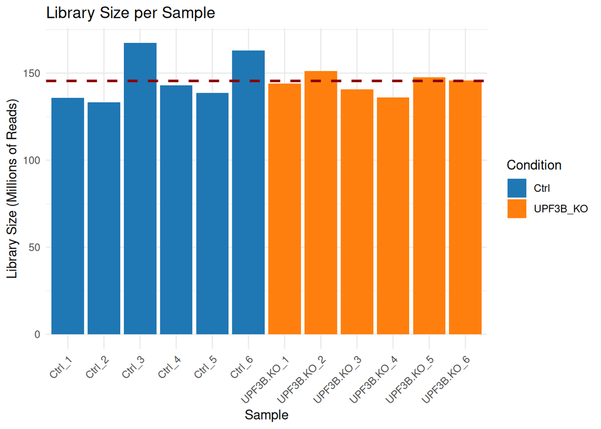

```r
library(ggplot2)

# Set conditions as Ctrl and UPF3B_KO
library_sizes$condition <- c(rep("Ctrl", 6), rep("UPF3B_KO", 6))

# Set unit as million
library_sizes$library_size_million <- library_sizes$library_size / 1e6

# Calculate the mean value across all samples
mean_library <- mean(library_sizes$library_size_million)

ggplot(library_sizes, aes(x = sample, y = library_size_million, fill = condition)) +
  geom_bar(stat = "identity") +
  geom_hline(yintercept = mean_library,
             linetype = "dashed",
             color = "darkred",
             size = 1) +
  theme_minimal() +
  theme(axis.text.x = element_text(angle = 45, hjust = 1)) +
  labs(title = "Library Size per Sample",
       x = "Sample",
       y = "Library Size (Millions of Reads)",
       fill = "Condition") +
  scale_fill_manual(values = c("Ctrl" = "#1f77b4", "UPF3B_KO" = "#ff7f0e"))
```

**Figure 1. Library sizes of each RNA-seq sample in the GSE263406 dataset.** Total read counts for each sample are shown in millions, with colors indicating experimental condition (blue = Control, orange = UPF3B knockout). This visualization allows comparison of sequencing depth across samples and helps identify potential outliers prior to downstream analyses.

## 2.4 Mapping to HUGO ids

In the GEO dataset, genes are annotated using Ensembl gene IDs, so I will map these Ensembl gene IDs to the corresponding HGNC symbols whenever such mappings exist. Package biomaRt (Durinck et al., 2005) is applied in this step. One gene was associated with two HGNC symbols; only the first mapping was retained.

```r
library(biomaRt)
library(dplyr)

# Save the cache file
cache_file <- "id_conversion.rds"

# Read in the file if it exist
if (file.exists(cache_file)) {
  id_mapping <- readRDS(cache_file)

} else {
  # Link to Ensembl
  ensembl <- useMart("ensembl")
  ensembl <- useDataset("hsapiens_gene_ensembl", mart = ensembl)

  # First time mapping ENSG to HUGO
  ensembl_ids <- unique(counts$Geneid)
  id_mapping <- getBM(
    attributes = c("ensembl_gene_id", "hgnc_symbol"),
    filters = "ensembl_gene_id",
    values = ensembl_ids,
    mart = ensembl
  )
  saveRDS(id_mapping, cache_file)  # Save the cache file
}

# Only keep unique mapping
id_mapping_unique <- id_mapping %>%
  group_by(ensembl_gene_id) %>%
  slice(1) %>%
  ungroup()

# Merge id_mapping with the original counts dataset
counts_with_hugo <- counts %>%
  left_join(id_mapping_unique, by = c("Geneid" = "ensembl_gene_id")) %>%
  dplyr::select(Geneid, hgnc_symbol, everything())

counts_hugo_only <- counts_with_hugo %>%
  filter(!is.na(hgnc_symbol) & hgnc_symbol != "")

counts_hugo_unique <- counts_hugo_only[!duplicated(counts_hugo_only$hgnc_symbol), ]

# Display id_mapping
paged_table(counts_hugo_unique[1:10,])
```

|  | Geneid | hgnc_symbol | Ctrl_1 | Ctrl_2 | Ctrl_3 | Ctrl_4 | Ctrl_5 | Ctrl_6 | UPF3B.KO_1 | UPF3B.KO_2 | UPF3B.KO_3 | UPF3B.KO_4 | UPF3B.KO_5 | UPF3B.KO_6 |
| --- | --- | --- | --- | --- | --- | --- | --- | --- | --- | --- | --- | --- | --- | --- |
| 1 | ENSG00000289716 | XNDC1N-ZNF705EP-ALG1L9P | 0 | 5 | 0 | 1 | 0 | 0 | 0 | 0 | 0 | 0 | 0 | 0 |
| 2 | ENSG00000289604 | CTAGE8 | 36 | 44 | 72 | 57 | 29 | 59 | 61 | 105 | 65 | 57 | 41 | 77 |
| 3 | ENSG00000289568 | COX8BP | 0 | 0 | 0 | 0 | 6 | 0 | 0 | 0 | 4 | 6 | 0 | 0 |
| 4 | ENSG00000289549 | PPIAL4D | 6 | 11 | 14 | 10 | 4 | 10 | 6 | 12 | 4 | 4 | 8 | 12 |
| 5 | ENSG00000289412 | ZEBTR | 8 | 8 | 4 | 18 | 4 | 4 | 6 | 4 | 4 | 4 | 0 | 6 |
| 6 | ENSG00000289313 | LINC01512 | 0 | 0 | 0 | 0 | 0 | 0 | 0 | 0 | 0 | 4 | 4 | 8 |
| 7 | ENSG00000289234 | ZNF496-DT | 2658 | 2712 | 3245 | 2928 | 2795 | 3232 | 2892 | 2824 | 2829 | 2843 | 3148 | 2959 |
| 8 | ENSG00000289228 | HECTD2-AS1 | 0 | 0 | 0 | 0 | 0 | 0 | 6 | 10 | 6 | 0 | 0 | 0 |
| 9 | ENSG00000289156 | PPP3R1-AS1 | 9 | 6 | 7 | 8 | 5 | 5 | 4 | 13 | 7 | 3 | 3 | 2 |
| 10 | ENSG00000289130 | THRB-AS2 | 0 | 0 | 6 | 0 | 8 | 6 | 0 | 0 | 0 | 0 | 0 | 0 |

**Table 3. Summary of HGNC mapping for the dataset.** Of the 43,884 original genes, 31,282 were successfully mapped to HGNC symbols. The table shows the first 10 rows after removing entries with missing HGNC symbols. Some genes in the dataset do not have corresponding HGNC symbols. In cases where a gene mapped to multiple HGNC symbols, only one representative symbol was retained. If an HGNC symbol corresponds to multiple Ensembl IDs, only the first one was retained.

# 3 Data normalization

## 3.1 Create expression matrix

The raw count data were first cleaned by removing duplicate or non-informative entries. The `hgnc_symbol` column was then set as the row names to uniquely identify each gene. The cleaned data frame was subsequently converted into a numeric matrix suitable for downstream analysis, such as log2 transformation, normalization, and visualization.

```r
library(reshape2)

clean_counts <- counts_hugo_unique
rownames(clean_counts) <- clean_counts$hgnc_symbol
clean_counts <- clean_counts[, !(names(clean_counts) %in% c("hgnc_symbol", "Geneid"))]

# Matrix transform
counts_mat <- as.matrix(clean_counts)

# Log2 transform
log2_counts <- log2(counts_mat + 1)
```

## 3.2 Visualizing raw counts distribution

To assess the overall expression distribution across samples prior to normalization, log2-transformed cleaned raw counts were visualized using both boxplots (Wickham, 2016) and density plots. Boxplots show the distribution of expression values for each sample, allowing detection of differences in library size or potential outlier samples. Density plots provide an overview of the global distribution of gene expression, illustrating the consistency across biological replicates and the general similarity between the two experimental conditions.

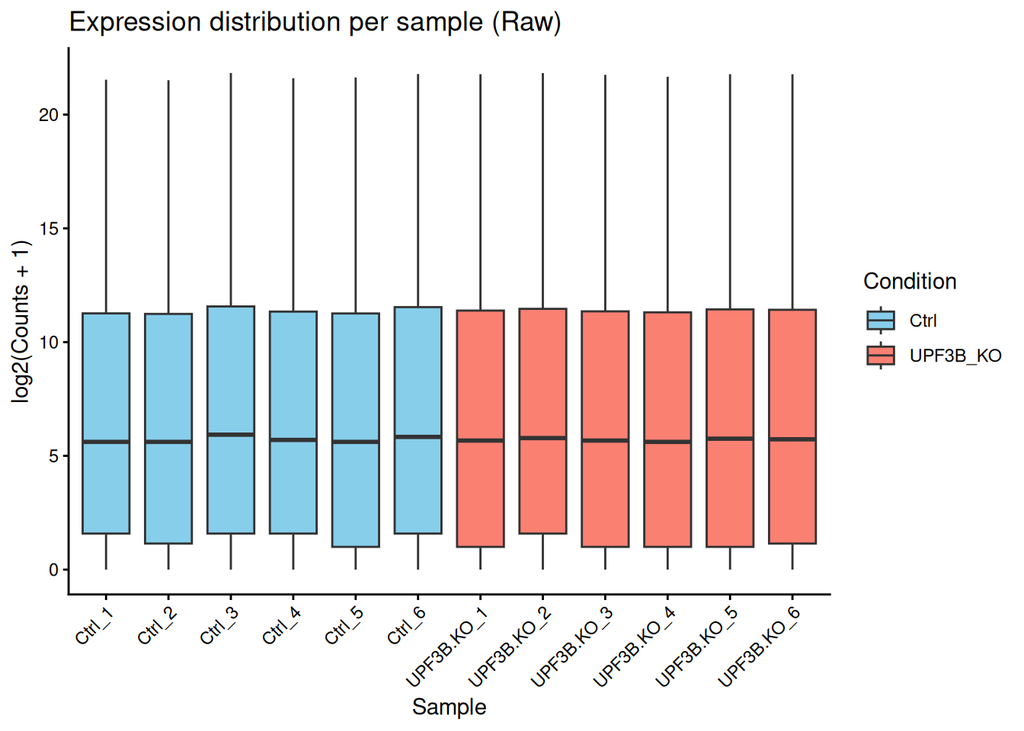

```r
library(ggplot2)

# Long form
df_long <- melt(log2_counts)
colnames(df_long) <- c("Gene","Sample","Expression")

# Add conditions
df_long$Condition <- rep(c(rep("Ctrl", 6), rep("UPF3B_KO", 6)),
                          each = nrow(log2_counts))

# Create boxplot
ggplot(df_long, aes(x = Sample, y = Expression, fill = Condition)) +
  geom_boxplot() +
  theme_classic() +
  theme(axis.text.x = element_text(angle = 45, hjust = 1)) +
  scale_fill_manual(values = c("skyblue", "salmon")) +
  labs(title = "Expression distribution per sample (Raw)",
       x = "Sample",
       y = "log2(Counts + 1)")
```

**Figure 2. Expression distribution of log2-transformed gene expression (Raw) across all samples.** Boxplots show the distribution of expression values for each sample, with six biological replicates for the control group (skyblue) and six for the UPF3B condition (salmon). The similar distribution of the boxes across replicates indicates consistent library size and normalization, with no obvious outlier samples.

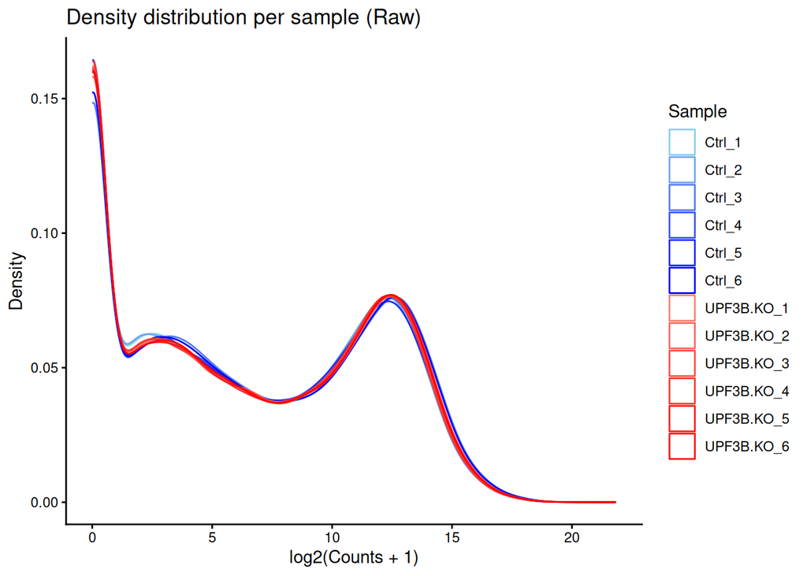

```r
library(reshape2)
library(ggplot2)

# Set colors for each sample
sample_colors <- c(
  colorRampPalette(c("skyblue","blue"))(6),
  colorRampPalette(c("salmon","red"))(6)
)

names(sample_colors) <- colnames(log2_counts)

# Create density plot
ggplot(df_long, aes(x = Expression, color = Sample)) +
  geom_density(size = 0.5, alpha = 0.5) +
  theme_classic() +
  labs(title = "Density distribution per sample (Raw)",
       x = "log2(Counts + 1)",
       y = "Density") +
  scale_color_manual(values = sample_colors)
```

**Figure 3. Density distribution of log2-transformed gene expression (Raw) across all samples.** Six biological replicates per condition are colored in gradient blue (Ctrl) or red (UPF3B_KO). The curves show comparable expression distributions across samples, suggesting consistent data quality before normalization.

## 3.3 Filtering low expressions

To focus on informative genes, lowly expressed genes were filtered using edgeR’s `filterByExpr()`, which removes genes with minimal read counts across samples (Chen et al., 2025). After filtering, 19197 genes remained for analysis, while 12085 lowly expressed genes were excluded from the 12-sample dataset.

```r
library("edgeR")

groups <- factor(c(rep("Ctrl", 6), rep("UPF3B_KO", 6)))

# Create a DGEList object
dge <- edgeR::DGEList(counts = counts_mat,
                      group = groups)

# Filter out lowly expressed genes
keep <- filterByExpr(dge, group = groups)
counts_remove_low <- counts_mat[keep, ]

n_genes_before <- nrow(counts_mat)
n_genes_after  <- nrow(counts_remove_low)

cat("Number of genes before filtering:", n_genes_before,
    "\nNumber of genes after filtering:", n_genes_after,
    "\nNumber of lowly expressed genes removed:", n_genes_before - n_genes_after, "\n")
```

```
## Number of genes before filtering: 31282
## Number of genes after filtering: 19197
## Number of lowly expressed genes removed: 12085
```

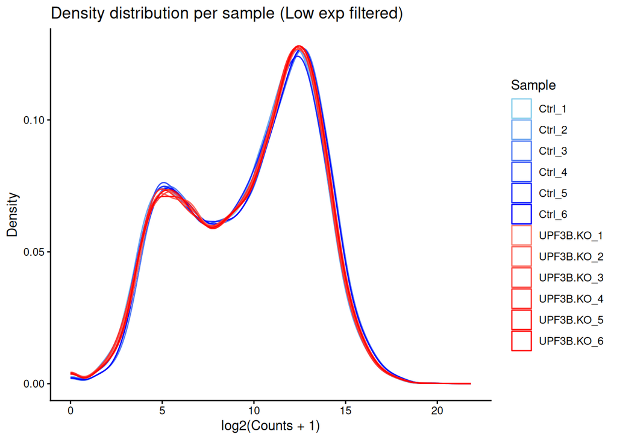

```r
library(reshape2)
library(ggplot2)

# Log2 transform
log2_remove_low <- log2(counts_remove_low + 1)

df_long_remove_low <- melt(log2_remove_low)
colnames(df_long_remove_low) <- c("Gene","Sample","Expression")

# Add condition info
df_long_remove_low$Condition <- rep(c(rep("Ctrl", 6), rep("UPF3B_KO", 6)),
                                    each = nrow(log2_remove_low))

# Assign colors per sample
ctrl_colors <- colorRampPalette(c("skyblue","blue"))(6)
upf_colors <- colorRampPalette(c("salmon","red"))(6)
sample_colors <- c(ctrl_colors, upf_colors)
names(sample_colors) <- colnames(log2_remove_low)

# Plot density distribution
ggplot(df_long_remove_low, aes(x = Expression, color = Sample)) +
  geom_density(size = 0.5, alpha = 0.5) +
  theme_classic() +
  labs(title = "Density distribution per sample (Low exp filtered)",
       x = "log2(Counts + 1)",
       y = "Density") +
  scale_color_manual(values = sample_colors)
```

**Figure 4. Density distribution of log2-transformed gene expression across all samples after low expression filtered.** Each line represents one biological replicate, with six replicates per condition. Ctrl samples are shown in shades of blue and UPF3B_KO samples in shades of red. After filtering, the large number of very lowly expressed genes (left tail) is removed, resulting in a distribution that is more centered and visually balanced across samples while preserving the overall expression patterns.

## 3.4 TMM normalization

TMM (Trimmed Mean of M-values) normalization (Robinson & Oshlack, 2010) is applied because the dataset consists of bulk RNA-seq data comparing control and UPF3B-KO human neural progenitor cells (NPCs). TMM is particularly suitable here as it adjusts for differences in library size and sequencing depth across samples, while assuming that the majority of genes are not differentially expressed—a reasonable assumption in this context since only a subset of mRNAs are expected to be sensitive to NMD. By trimming extreme high- and low-expression genes, TMM provides stable normalization factors that preserve the relative expression of most transcripts, allowing us to accurately quantify differential expression of UPF3B-target RNAs in NPCs. This approach is widely recommended for bulk RNA-seq datasets with multiple replicates per condition, such as ours with six replicates per group.

```r
library(edgeR)

groups <- factor(c(rep("Ctrl", 6), rep("UPF3B_KO", 6)))

# Create DGEList object
dge_norm <- edgeR::DGEList(counts = counts_remove_low, group = groups)

# TMM normalization
dge_norm <- calcNormFactors(dge_norm, method = "TMM")

# normalized CPM (counts per million)
norm_cpm <- cpm(dge_norm, normalized.lib.sizes = TRUE)
norm_cpm_df <- as.data.frame(norm_cpm)
norm_cpm_df <- norm_cpm_df[order(rownames(norm_cpm_df)), ]

# Check normalization factors
# dge$samples$norm.factors

paged_table(norm_cpm_df[1:10,])
```

|  | Ctrl_1 | Ctrl_2 | Ctrl_3 | Ctrl_4 | Ctrl_5 | Ctrl_6 | UPF3B.KO_1 | UPF3B.KO_2 | UPF3B.KO_3 | UPF3B.KO_4 | UPF3B.KO_5 | UPF3B.KO_6 |
| --- | --- | --- | --- | --- | --- | --- | --- | --- | --- | --- | --- | --- |
| A1BG | 0.2239310 | 0.2360682 | 0.30428711 | 0.17470427 | 0.30615987 | 0.20664549 | 0.29746508 | 0.2830205 | 0.2739197 | 0.5029650 | 0.1440662 | 0.3365803 |
| A1BG-AS1 | 1.1356500 | 1.4245496 | 1.25599359 | 1.22292992 | 0.77717506 | 0.97323359 | 1.21217019 | 0.8490615 | 1.0271990 | 1.1709653 | 1.0876999 | 0.8195000 |
| A1CF | 0.1999384 | 0.0488417 | 0.07121613 | 0.07595838 | 0.07850253 | 0.06665984 | 0.07436627 | 0.4103797 | 0.1902220 | 0.5579767 | 0.3529622 | 0.4243839 |
| A2M | 65.0519513 | 64.0233270 | 65.91376672 | 68.56003365 | 62.76277413 | 65.67993561 | 3.98603204 | 4.8184242 | 4.4283691 | 4.6209905 | 4.3147829 | 4.7852945 |
| A2M-AS1 | 2.0873567 | 2.3362613 | 2.34365814 | 1.99770539 | 1.76630696 | 1.85314342 | 2.27560784 | 3.0707726 | 1.9098293 | 2.4755307 | 2.7084447 | 2.4511830 |
| A4GALT | 0.7357732 | 0.7977477 | 0.89343874 | 0.46334612 | 0.77717506 | 0.63326843 | 0.31977496 | 0.2334919 | 0.1521776 | 0.2279060 | 0.5474516 | 0.1243884 |
| AAAS | 52.7517422 | 53.5874840 | 50.57640169 | 51.52256905 | 47.39197841 | 54.56774108 | 47.14821477 | 48.1134874 | 48.8718465 | 49.1412481 | 48.8888669 | 48.2553782 |
| AACS | 18.0824271 | 18.3481982 | 20.63972972 | 19.98464974 | 16.80739205 | 20.06461039 | 20.53252697 | 19.6982278 | 20.7950734 | 19.6785040 | 20.5582475 | 20.5167673 |
| AADAT | 26.2719031 | 27.5222974 | 25.61191054 | 26.00814926 | 25.43482029 | 26.85724760 | 30.63146635 | 31.7053731 | 33.7073455 | 31.1681097 | 30.1530568 | 32.8165840 |
| AAGAB | 169.8116650 | 163.1801162 | 163.49281515 | 162.20152433 | 176.70134871 | 165.05641790 | 181.62473965 | 186.0152327 | 187.5284957 | 177.1772652 | 178.4620122 | 176.6168795 |

**Table 4. Counts-per-million (CPM) values for each gene across all samples following TMM normalization and low-expression filtering.** These normalized expression levels account for variations in library size and RNA composition between samples, facilitating reliable comparison of gene activity across the Ctrl and UPF3B_KO groups. For clarity, only the first 10 rows are shown.

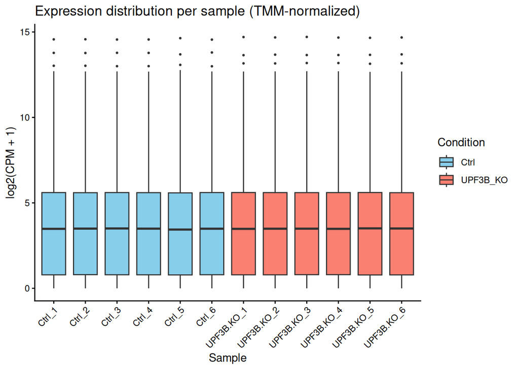

```r
library(reshape2)
library(ggplot2)

# log2 transform
log2_norm_cpm <- log2(norm_cpm + 1)

df_long_norm <- melt(log2_norm_cpm)
colnames(df_long_norm) <- c("Gene","Sample","Expression")

# Add condition info
df_long_norm$Condition <- rep(c(rep("Ctrl", 6), rep("UPF3B_KO", 6)),
                              each = nrow(log2_norm_cpm))

# Set colors
ctrl_colors <- colorRampPalette(c("skyblue","blue"))(6)
upf_colors <- colorRampPalette(c("salmon","red"))(6)
sample_colors <- c(ctrl_colors, upf_colors)
names(sample_colors) <- colnames(log2_norm_cpm)

# Box plot
ggplot(df_long_norm, aes(x = Sample, y = Expression, fill = Condition)) +
  geom_boxplot(outlier.size=0.5) +
  scale_fill_manual(values=c("Ctrl"="skyblue","UPF3B_KO"="salmon")) +
  theme_classic() +
  labs(title="Expression distribution per sample (TMM-normalized)",
       y="log2(CPM + 1)",
       x="Sample") +
  theme(axis.text.x = element_text(angle=45, hjust=1))
```

**Figure 5. Expression distribution of log2-transformed CPM values after TMM normalization and low-expression filtering.** Each box represents one biological replicate, with six replicates per condition. Compared to the raw counts (Figure 2.), the interquartile ranges and medians of all samples are more aligned, reflecting that library size differences and compositional biases have been corrected. The removal of lowly expressed genes also eliminates the extreme low-count tail, resulting in distributions that are more centered and comparable across samples. These normalized data are suitable for downstream analyses, including density visualization, multidimensional scaling (MDS), and differential expression testing.

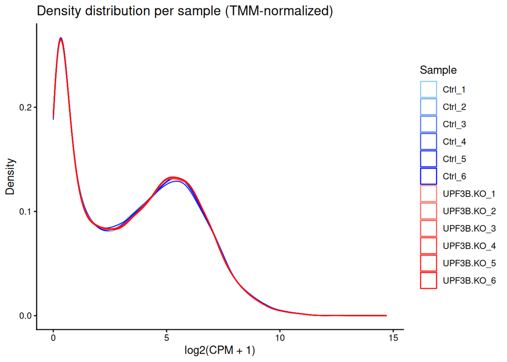

```r
library(ggplot2)

# Density plot
ggplot(df_long_norm, aes(x = Expression, color = Sample)) +
  geom_density(size=0.5, alpha=0.5) +
  scale_color_manual(values = sample_colors) +
  theme_classic() +
  labs(title="Density distribution per sample (TMM-normalized)",
       x="log2(CPM + 1)",
       y="Density")
```

**Figure 6. Expression distribution of log2-transformed CPM values after TMM normalization.** Each line represents one biological replicate, with six replicates per condition. The lines from all twelve samples overlap more closely compared to raw counts (Figure 3.), indicating that library size and compositional differences have been effectively corrected. A prominent peak is observed at low log2CPM values (~0–2), reflecting the natural accumulation of lowly expressed genes in bulk RNA-seq data. This peak is expected and does not indicate a normalization issue. Overall, the distributions demonstrate that the normalized data are suitable for downstream analyses, such as multidimensional scaling (MDS) and differential expression testing.

# 4 Differential expression analysis

## 4.1 Multidimensional scaling

To evaluate sample similarity and variability, multidimensional scaling (MDS) (Chen et al., 2025) was performed on TMM-normalized log2 CPM values. This projects high-dimensional gene expression data into two dimensions, allowing visualization of replicate clustering and separation between experimental conditions, and enabling assessment of normalization effectiveness and data quality for downstream analyses.

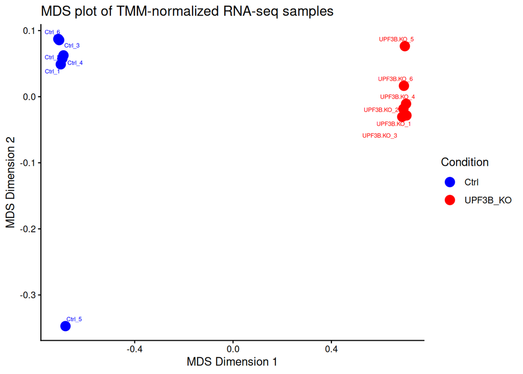

```r
library(edgeR)
library(ggplot2)
library(ggrepel)

groups <- factor(c(rep("Ctrl", 6), rep("UPF3B_KO", 6)))

mds <- plotMDS(log2_norm_cpm, plot=FALSE)

mds_df <- data.frame(
  Sample = colnames(log2_norm_cpm),
  MDS1 = mds$x,
  MDS2 = mds$y,
  Condition = groups
)

# ggplot2 visualization
ggplot(mds_df, aes(x = MDS1, y = MDS2, color = Condition)) +
  geom_point(size = 4) +
  geom_text_repel(aes(label=Sample),
                  size=2,
                  segment.size = 0) +
  scale_color_manual(values=c("Ctrl"="blue", "UPF3B_KO"="red")) +
  theme_classic() +
  labs(title="MDS plot of TMM-normalized RNA-seq samples",
       x="MDS Dimension 1",
       y="MDS Dimension 2")
```

## 4.2 Biological coefficient of variation plot

Differential expression analysis was performed using the edgeR package (Chen et al., 2025). edgeR was selected because it models RNA-seq count data using a negative binomial framework and incorporates TMM normalization to account for library size and compositional differences between samples. Given the moderate number of biological replicates per group (Ctrl vs UPF3B_KO), edgeR’s dispersion estimation and quasi-likelihood framework provide robust control of false positives while maintaining statistical power.

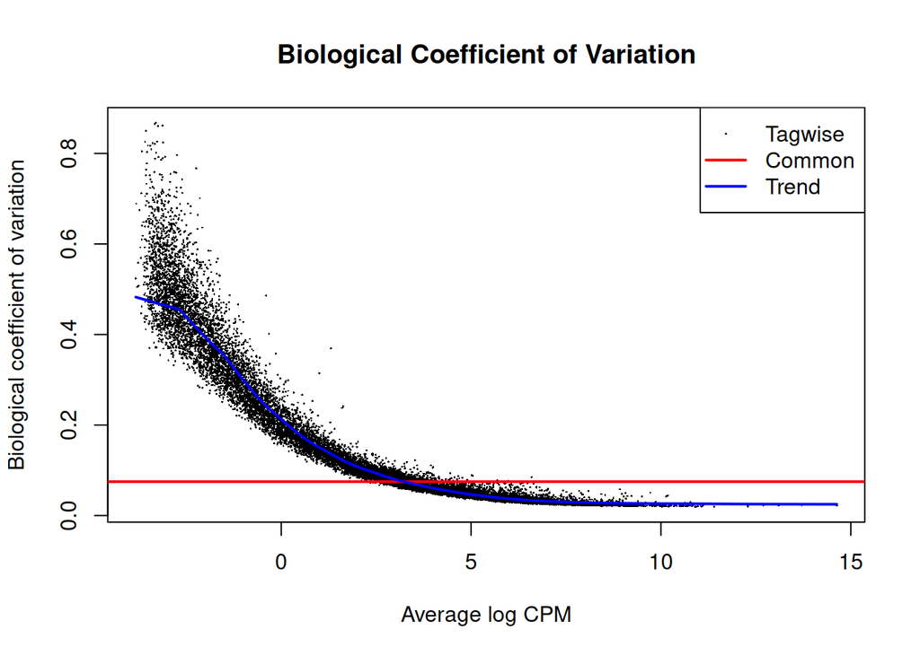

```r
library(edgeR)

# Create design matrix
group <- factor(dge_norm$samples$group)
design <- model.matrix(~ group)

dge_norm <- estimateDisp(dge_norm, design)

# Plotting BCV
edgeR::plotBCV(dge_norm, main = "Biological Coefficient of Variation")
```

## 4.3 Calculating p-values & multiple hypothesis testing

Differential expression analysis was performed using the quasi-likelihood F-test in edgeR. P-values were calculated for each gene to assess the significance of expression differences between Ctrl and UPF3B_KO samples.

```r
library(dplyr)

fit <- glmQLFit(dge_norm, design)
qlf <- glmQLFTest(fit, coef = 2)

qlf_table <- topTags(qlf, n = Inf)$table

# Pass FDR
FDR <- sum(qlf_table$FDR < 0.05)

# Pass FDR + fold change
FDR_FC <- sum(qlf_table$FDR < 0.05 & abs(qlf_table$logFC) > 1)

# export significant genes
sig_genes <- qlf_table[qlf_table$FDR < 0.05 & abs(qlf_table$logFC) > 1, ]
sig_genes$gene_name <- row.names(sig_genes)
sig_genes <- sig_genes %>%
  dplyr::select(gene_name, everything())

setwd("/home/rstudio/projects/A1")
outfile <- "../A2/data/sig_genes.csv"
dir.create(dirname(outfile), recursive = TRUE, showWarnings = FALSE)
if (!file.exists(outfile)) {
  write.csv(sig_genes, outfile, row.names = FALSE)
  message("CSV file created: ", outfile)
} else {
  message("File already exists, skipping write: ", outfile)
}

qlf_table$gene_name <- row.names(qlf_table)
deafile <- "../A2/data/DEA_result.csv"
if (!file.exists(deafile)) {
  write.csv(qlf_table, deafile, row.names = FALSE)
  message("DEA CSV file created: ", deafile)
} else {
  message("DEA File already exists, skipping write: ", deafile)
}

cat("Number of genes passing FDR < 0.05:", FDR,
    "\nNumber of genes passing FDR < 0.05 and |log2FC| > 1:", FDR_FC, "\n")
```

```
## Number of genes passing FDR < 0.05: 9429
## Number of genes passing FDR < 0.05 and |log2FC| > 1: 1209
```

```r
paged_table(qlf_table[1:10, ])
```

|  | logFC | logCPM | F | PValue | FDR | gene_name |
| --- | --- | --- | --- | --- | --- | --- |
| ANGPTL7 | 6.835500 | 5.483265 | 14943.543 | 8.537611e-39 | 1.249489e-34 | ANGPTL7 |
| SCGN | -1.865540 | 8.599340 | 14467.647 | 1.301755e-38 | 1.249489e-34 | SCGN |
| IGFBPL1 | -2.549908 | 6.427527 | 8760.806 | 1.171899e-35 | 7.498979e-32 | IGFBPL1 |
| A2M | -3.862004 | 5.126201 | 7555.266 | 8.713117e-35 | 4.181643e-31 | A2M |
| COL3A1 | -3.312867 | 5.534678 | 6460.026 | 7.264501e-34 | 2.789133e-30 | COL3A1 |
| EPHA7 | -2.728252 | 5.685520 | 5628.852 | 4.684559e-33 | 1.498825e-29 | EPHA7 |
| LPL | -3.808568 | 4.562189 | 5137.540 | 1.612085e-32 | 4.264618e-29 | LPL |
| TIMP3 | -1.646585 | 6.611267 | 5100.464 | 1.777202e-32 | 4.264618e-29 | TIMP3 |
| CCN2 | -1.323181 | 7.188101 | 4955.603 | 2.623888e-32 | 5.318680e-29 | CCN2 |
| GNAS | 0.829043 | 10.714109 | 4935.706 | 2.770579e-32 | 5.318680e-29 | GNAS |

**Table 5. Differentially expressed genes identified between Ctrl and UPF3B_KO samples.** The table shows the top genes ranked by quasi-likelihood F-test results from edgeR, including log2 fold change, logCPM, F-statistic, p-value, and FDR (Benjamini-Hochberg corrected). Using an FDR cutoff of 0.05, 9429 genes were considered significantly differentially expressed. Applying an additional threshold of |log2FC| > 1 yielded 1209 high-confidence genes. For clarity, only the first 10 rows and first 10 columns are shown.

## 4.4 Volcano plot

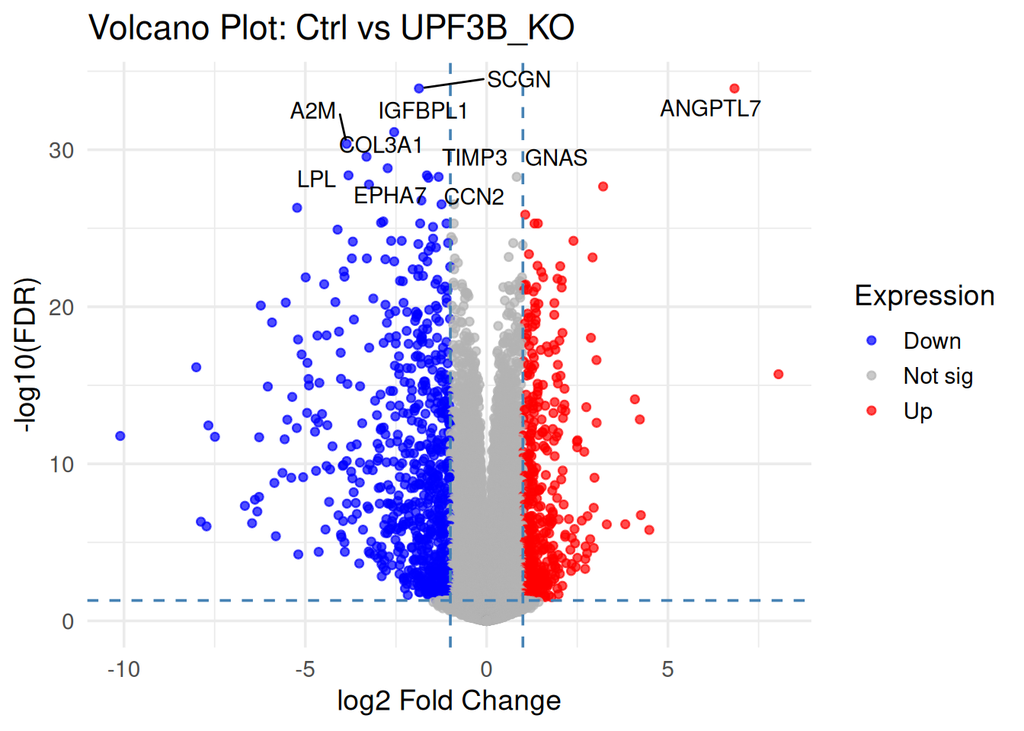

```r
library(ggplot2)
library(ggrepel)
library(dplyr)

qlf_table$genes <- rownames(qlf_table)

# Build dataframe
volcano_df <- qlf_table %>%
  mutate(
    direction = case_when(
      FDR < 0.05 & logFC > 1  ~ "Up",
      FDR < 0.05 & logFC < -1 ~ "Down",
      TRUE ~ "Not sig"
    ),
    Significant = FDR < 0.05
  )

# Mark genes to label
genes_to_label <- c(
  head(volcano_df[order(volcano_df$FDR), "genes"], 10)
)

volcano_df <- volcano_df %>%
  mutate(label = if_else(genes %in% genes_to_label, genes, NA_character_))

# Plot
ggplot(volcano_df, aes(x = logFC, y = -log10(FDR))) +
  geom_point(aes(color = direction), alpha = 0.7, size = 1.5) +
  geom_vline(xintercept = c(-1, 1), linetype = "dashed", color = "steelblue") +
  geom_hline(yintercept = -log10(0.05), linetype = "dashed", color = "steelblue") +
  geom_text_repel(aes(label = label),
                  na.rm = TRUE,
                  box.padding = 0.3,
                  point.padding = 0.2,
                  max.overlaps = 10) +
  scale_color_manual(values = c("Up" = "red", "Down" = "blue", "Not sig" = "grey70")) +
  theme_minimal(base_size = 14) +
  labs(
    title = "Volcano Plot: Ctrl vs UPF3B_KO",
    x = "log2 Fold Change",
    y = "-log10(FDR)",
    color = "Expression"
  )
```

**Figure 9. Volcano plot of differential gene expression between UPF3B_KO and Ctrl samples.** Each point represents a gene, with the x-axis showing log2 fold change (UPF3B_KO relative to Ctrl) and the y-axis showing -log10(FDR). Red points indicate significantly up-regulated genes (n = 482), blue points indicate significantly down-regulated genes (n = 727), and grey points indicate non-significant genes (n = 17,988). Ten most significant hits (passing FDR < 0.05) are labeled. The dashed vertical lines mark log2 fold-change thresholds (+-1) and the horizontal line marks the FDR cutoff (0.05), highlighting genes with biologically meaningful and statistically significant expression changes.

```r
up_genes <- sum(volcano_df$FDR < 0.05 & volcano_df$logFC > 1)
down_genes <- sum(volcano_df$FDR < 0.05 & volcano_df$logFC < -1)
not_sig_genes <- sum(!(volcano_df$FDR < 0.05 & abs(volcano_df$logFC) > 1))

cat("Up-regulated genes:", up_genes,
    "\nDown-regulated genes:", down_genes,
    "\nNot significant genes:", not_sig_genes)
```

```
## Up-regulated genes: 482
## Down-regulated genes: 727
## Not significant genes: 17988
```

In human neural progenitor cells (NPCs), UPF3B knockout leads to a greater number of down-regulated genes (n = 727) compared with up-regulated genes (n = 482), indicating that loss of UPF3B probably reduces target gene expression in this cell type. This pattern contrasts with observations in human embryonic stem cells (ESCs), where UPF3B disruption has been reported to produce a more balanced or even opposite effect on gene expression. These results suggest that UPF3B’s regulatory impact is highly context-dependent and may vary across developmental stages.

## 4.5 Top hits - Heatmap

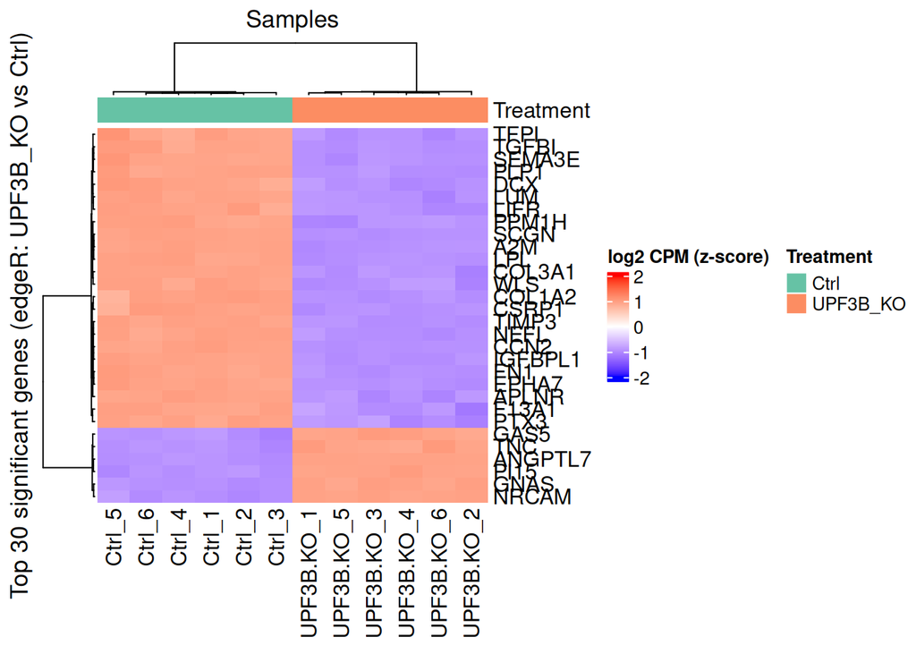

```r
library(ComplexHeatmap)
library(circlize)
library(RColorBrewer)

top_hits <- qlf_table %>%
  arrange(FDR) %>%
  head(30) %>%
  pull(genes)

heatmap_matrix <- log2_norm_cpm[top_hits, ]

# Z-score
hm_z <- t(scale(t(heatmap_matrix)))

# Sample notation
treatment_data <- as.factor(dge_norm$samples$group)
treat_levels <- levels(treatment_data)
treat_cols <- setNames(
  brewer.pal(max(2, length(treat_levels)), "Set2")[seq_along(treat_levels)],
  treat_levels
)

annot <- HeatmapAnnotation(
  Treatment = treatment_data,
  col = list(Treatment = treat_cols),
  annotation_legend_param = list(Treatment = list(title = "Treatment"))
)

# Color function
color_function <- colorRamp2(c(-2, 0, 2), c("blue", "white", "red"))

# Heatmap plotting
Heatmap(
  hm_z,
  name = "log2 CPM (z-score)",
  col = color_function,
  top_annotation = annot,
  show_row_names = TRUE,
  show_column_names = TRUE,
  cluster_rows = TRUE,
  cluster_columns = TRUE,
  row_title = "Top 30 significant genes (edgeR: UPF3B_KO vs Ctrl)",
  column_title = "Samples"
)
```

**Figure 10. Heatmap of top 30 significant genes from UPF3B_KO vs Ctrl samples.** Each row represents a gene (z-score scaled log2 CPM) and each column represents a sample. Red indicates higher relative expression and blue indicates lower relative expression. Genes cluster into two major groups, showing complementary expression patterns: genes up-regulated in UPF3B_KO are generally down-regulated in Ctrl, and vice versa. Samples cluster clearly by treatment condition, with all Ctrl samples grouping together and all UPF3B_KO samples grouping together.

# 5 Conclusion

I analyzed bulk RNA-seq data from human neural progenitor cells (NPC) comparing UPF3B knockout (UPF3B_KO) to controls. After quality control, low-expression filtering, and TMM normalization, exploratory visualizations (boxplots, density plots, and MDS) confirmed sample integrity and guided model design. Differential expression analysis using edgeR revealed that UPF3B loss predominantly down-regulates target genes in NPCs, consistent with previous findings in the original study (Tan et al., 2025). Heatmaps and volcano plots showed clear treatment-driven patterns, with samples clustering by condition and top genes displaying complementary expression changes. These results support the conclusion that UPF3B might play a critical, context-dependent role in regulating gene expression during NPC differentiation.

### Why is the dataset of interest to you?

I am particularly interested in the physiological mechanisms underlying neurodevelopmental disorders. This dataset allows me to investigate the role of UPF3B, a key factor in the nonsense-mediated mRNA decay (NMD) pathway, in human neural progenitor cells. Comparing UPF3B knockout and control cells enables identification of genes affected by UPF3B loss and provides insights into cell type-specific regulation relevant to neurodevelopment.

### What are the control and test conditions of the dataset?

The control condition consists of neural progenitor cells (NPCs) derived from human embryonic stem cells with intact UPF3B expression (Ctrl). The test condition consists of NPCs in which UPF3B has been knocked out (UPF3B_KO). Comparing these two conditions allows the assessment of how UPF3B loss affects gene expression and NMD sensitivity in NPCs.

### How many samples in each of the conditions of your dataset?

There are six biological replicates for each condition in this dataset, with six Ctrl samples and six UPF3B_KO samples, providing sufficient replication to assess differential gene expression reliably.

### Were there expression values that were not unique for specific genes? How did you handle these?

Yes. For genes mapping to multiple HGNC symbols, only one representative symbol was retained, and if an HGNC symbol corresponded to multiple Ensembl IDs, only the first ID was kept.

### Were there expression values that could not be mapped to current HUGO symbols?

Of the 43,884 original genes, 31,282 were successfully mapped to HGNC symbols. Genes without an HGNC symbol (N = 12602) were removed.

### Were there any outliers in your dataset? How were they handled in the originating paper? How many outliers were removed?

No extreme outliers were detected in the dataset after initial quality control and low-expression filtering. In the originating study, standard quality control procedures were applied to remove samples or genes with abnormal expression patterns, although specific numbers of removed outliers were not reported.

### How did you handle replicates?

All biological replicates were retained for analysis. Each condition (Ctrl and UPF3B_KO) included six replicates, and they were treated as independent samples in the model design for differential expression analysis. Replicate consistency was confirmed using exploratory visualizations such as boxplots, density plots, and MDS, ensuring that variation within replicates was smaller than variation between conditions.

### What is the final coverage of your dataset?

```r
# Export normalized expression data
setwd("/home/rstudio/projects/A1")
expfile <- "../A2/data/Expression_norm.txt"

if (!file.exists(expfile)) {
  write.table(
  log2_norm_cpm,
  file = expfile,
  sep = "\t",
  row.names = TRUE,
  col.names = TRUE,
  quote = FALSE
)
  message("DEA CSV file created: ", expfile)
} else {
  message("DEA File already exists, skipping write: ", expfile)
}
```

# 6 Link to journal entry

A1 journal entry could be found [here](https://github.com/bcb420-2026/Feiyang_Sun/wiki/Assignment-1)

# References

Benjamini, Y., & Hochberg, Y. (1995). Controlling the false discovery rate: A practical and powerful approach to multiple testing. *Journal of the Royal Statistical Society: Series B (Methodological)*, *57*(1), 289–300.

Chen, Y., Chen, L., Lun, A. T. L., Baldoni, P., & Smyth, G. K. (2025). edgeR v4: Powerful differential analysis of sequencing data with expanded functionality and improved support for small counts and larger datasets. *Nucleic Acids Research*, *53*(2), gkaf018. https://doi.org/10.1093/nar/gkaf018

Davis, S., & Meltzer, P. (2007). GEOquery: A bridge between the gene expression omnibus (GEO) and BioConductor. *Bioinformatics*, *14*, 1846–1847. https://doi.org/10.1093/bioinformatics/btm254

Durinck, S., Moreau, Y., Kasprzyk, A., Davis, S., De Moor, B., Brazma, A., & Huber, W. (2005). BioMart and bioconductor: A powerful link between biological databases and microarray data analysis. *Bioinformatics*, *21*, 3439–3440.

Gu, Z. (2022). Complex heatmap visualization. *iMeta*. https://doi.org/10.1002/imt2.43

Karousis, E. D., Nasif, S., & Mühlemann, O. (2016). Nonsense-mediated mRNA decay: Novel mechanistic insights and biological impact. *WIREs RNA*, *7*(5), 661–682. https://doi.org/10.1002/wrna.1357

Morgan, M., & Ramos, M. (2025). *BiocManager: Access the bioconductor project package repository*. https://doi.org/10.32614/CRAN.package.BiocManager

Müller, K., & Wickham, H. (2025). *Tibble: Simple data frames*. https://tibble.tidyverse.org/

R Core Team. (2025). *R: A language and environment for statistical computing*. R Foundation for Statistical Computing. https://www.R-project.org/

Robinson, M. D., & Oshlack, A. (2010). A scaling normalization method for differential expression analysis of RNA-seq data. *Genome Biology*, *11*(3), R25. https://doi.org/10.1186/gb-2010-11-3-r25

Tan, K., Sebat, J., & Wilkinson, M. F. (2025). Cell type- and factor-specific nonsense-mediated RNA decay. *Nucleic Acids Res*, *53*(9), gkaf395. https://doi.org/10.1093/nar/gkaf395

Wickham, H. (2016). *ggplot2: Elegant graphics for data analysis*. Springer-Verlag New York. https://ggplot2.tidyverse.org

Wickham, H., François, R., Henry, L., Müller, K., & Vaughan, D. (2023). *Dplyr: A grammar of data manipulation*. https://doi.org/10.32614/CRAN.package.dplyr